# Merger with complements and bundling: The case of Claro, Colombia

JS Vélez

October 08, 2015

## tables & figures

[interactive chart not shown]

Mean download speed

| who.in.town | n.be | speed.be | n.af | speed.af | diff | lb95 | ub95 |
| --- | --- | --- | --- | --- | --- | --- | --- |
| none.in.town | 4065 | 1.19 | 4836 | 1.86 | 0.67 | 0.62 | 0.72 |
| telmex.in.town | 4794 | 2.54 | 5531 | 3.61 | 1.06 | 0.96 | 1.16 |
| coltel.in.town | 7542 | 1.52 | 7554 | 1.69 | 0.17 | 0.14 | 0.20 |
| both.in.town | 13544 | 2.36 | 17233 | 3.15 | 0.79 | 0.73 | 0.84 |

<sub>Download speed in Mb/s. Before: 2010q4-2012q2. After: 2012q3-2013q4. lb95 and ub95 are the 95% CI upper and lower bounds for the difference.</sub>

Mean number of subscribers

| who.in.town | n.be | subs.be | n.af | subs.af | diff | lb95 | ub95 |
| --- | --- | --- | --- | --- | --- | --- | --- |
| none.in.town | 4065 | 151.14 | 4836 | 160.83 | 9.69 | -4.85 | 24.24 |
| telmex.in.town | 4794 | 937.49 | 5531 | 836.45 | -101.04 | -250.77 | 48.69 |
| coltel.in.town | 7542 | 117.73 | 7554 | 143.62 | 25.89 | 17.28 | 34.49 |
| both.in.town | 13544 | 987.20 | 17233 | 929.30 | -57.90 | -168.72 | 52.92 |

<sub>Number of subscribers by plan. Before: 2010q4-2012q2. After: 2012q3-2013q4. lb95 and ub95 are the 95% CI upper and lower bounds for the difference.</sub>

Mean number of plans per firm per city

| who.in.town | n.be | plans.be | n.af | plans.af | diff | lb95 | ub95 |
| --- | --- | --- | --- | --- | --- | --- | --- |
| none.in.town | 4065 | 8.16 | 4836 | 10.25 | 2.09 | 1.76 | 2.43 |
| telmex.in.town | 4794 | 35.46 | 5531 | 36.58 | 1.12 | 0.02 | 2.22 |
| coltel.in.town | 7542 | 7.18 | 7554 | 7.60 | 0.42 | 0.28 | 0.55 |
| both.in.town | 13544 | 20.79 | 17233 | 24.09 | 3.30 | 2.97 | 3.63 |

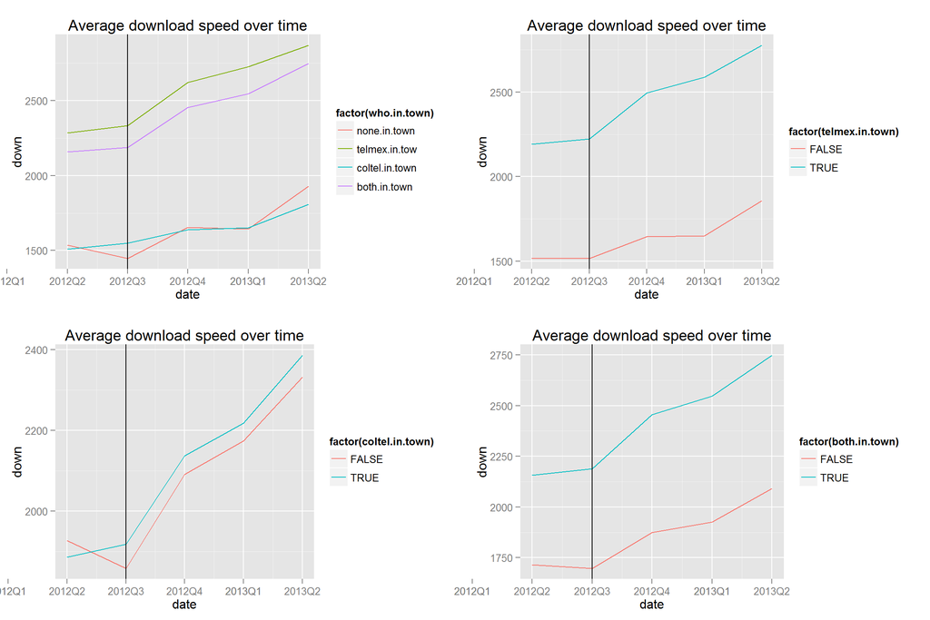

## Policies

1. Starting on September 2011 (and ending in September 2013) 0% tariff on computer imports. The tariff used to be 5%. Decree 2917 of 2011.
2. Internet services are subsidized for strata 1 and 2 (the poorer). It started on September 2012 and the government had spent $20 million by March 2013. Law 1450 of 2009.
3. No VAT for internet subscribers in strata 1 and 2 starting in January 2013. Law 1430 of 2010

## Regressions

### Download speed

$$speed_{ijct} = \mu + \delta_{s,t} + \alpha_j + \gamma_1 coltel\_merged_{jt} + \gamma_2 telmex\_merged_{jt} +
\phi_1 coltel\_merged\_in\_city_{ct} + \\
\phi_2 coltel\_merged\_in\_city_{ct} +
\phi_3 both\_merged\_in\_city_{ct} + \varepsilon_{ijct}$$

Effect of competing with Telmex, Coltel or Both

|  | Model 1 | SE 1 | S1 | Model 2 | SE 2 | S2 |
| --- | --- | --- | --- | --- | --- | --- |
| (Intercept) | 2868.86 | 1097.31 | ** | 1488.32 | 1311.69 |  |
| firmCOLOMBIA TELECOMUNICACIONES S.A. ESP | -1915.86 | 398.34 | *** | -535.32 | 660.64 |  |
| firmTELMEX COLOMBIA S.A. | -413.28 | 398.33 |  | 980.45 | 659.81 |  |
| col.mergedTRUE | -377.45 | 55.48 | *** | -435.37 | 85.12 | *** |
| tel.mergedTRUE | 922.32 | 60.94 | *** | 966.44 | 86.88 | *** |
| col.merged.cityTRUE | 367.91 | 67.10 | *** | 421.59 | 108.12 | *** |
| tel.merged.cityTRUE | 614.21 | 63.22 | *** | 686.51 | 96.13 | *** |
| both.merged.cityTRUE | -169.72 | 72.78 | * | -101.68 | 112.08 |  |
| adj. R-squared | 0.24 | NA | NA | 0.23 | NA | NA |
| Observations | 41087.00 | NA | NA | 22181.00 | NA | NA |

### Prices

$$\ln price_{ijct} = \mu + \delta_{s,t} + \alpha_j + \gamma_2 telmex\_merged_{jt} +
\phi_1 coltel\_merged\_in\_city_{ct} + \\
\phi_2 coltel\_merged\_in\_city_{ct} +
\phi_3 both\_merged\_in\_city_{ct} + \varepsilon_{ijct}$$

Effect of Telmex’s merger on price per Mb

|  | Model 1 | SE 1 | S1 | Model 2 | SE 2 | S2 |
| --- | --- | --- | --- | --- | --- | --- |
| (Intercept) | 11.04 | 0.24 | *** | 11.02 | 0.26 | *** |
| firmTELMEX COLOMBIA S.A. | -1.94 | 0.24 | *** | -2.02 | 0.26 | *** |
| is.mergedTRUE | -0.05 | 0.01 | *** | -0.02 | 0.01 | ** |
| col.in.townTRUE | 0.09 | 0.01 | *** | 0.10 | 0.02 | *** |
| col.merged.cityTRUE | -0.09 | 0.02 | *** | -0.08 | 0.02 | *** |
| tel.merged.cityTRUE | -0.08 | 0.00 | *** | -0.07 | 0.01 | *** |
| both.merged.cityTRUE | -0.01 | 0.01 |  | -0.02 | 0.01 |  |
| adj. R-squared | 0.74 | NA | NA | 0.72 | NA | NA |
| Observations | 294709.00 | NA | NA | 189784.00 | NA | NA |

<sub>Dependent Variable: Natural logarithm of dollars per Mbps. Model 1: state and firm-quarter FE Model 2: same as 1 but drops plans affected by the confounding policies. Signif. codes: 0(***) 0.001(**) 0.01(*) 0.05(.)</sub>